# II - Libraries for science: Numpy, Matplotlib, Scipy

## II-4-b Indexing with booleans

- One can apply a condition directly on an array.
- This will create an array of boolean of the exact same length with the value at `True` where the condition is satisfied.
- This boolean array can be used to index the initial array.
- This will create a sub-array with the values satifying the condition.
- Let's try on the previous array to extract the even values.

```python
print(tab_1)
```

```
[ 1 24  5 36 42  9  8 11]
```

```python
cond_1 = (tab_1%2 == 0)
print(cond_1)
```

```
[False  True False  True  True False  True False]
```

```python
print(tab_1[cond_1])
```

```
[24 36 42  8]
```

- This can be written in an even a more compact way to cut undesired values:

```python
tab_2 = tab_1[tab_1%2 == 0]
```

- If the values of the indices is required, the boolean array can be passes to the `where` function.

```python
print(np.where(cond_1))
```

```
(array([1, 3, 4, 6]),)
```

### II-4-c Combining conditions - bitwise operations

- It is sometimes necessary to apply several condition at ones.
- Each condition will generate its boolean array which can then be combined followin bool algebra, using bitwise operators.
- Be carefull !!!
  - The standard boolean operators `and` et `or` previoulsly seen wont work here.
  - One has to use the bitwise operator `&`, and `|` and `~` for **and**, **or** and **not** operations on boolean arrays.
- Let's go back to or previous example and say that we now want both even values an values greater than 30.

```python
print(tab_1)
print(cond_1) # condition of even values
```

```
[ 1 24  5 36 42  9  8 11]
[False  True False  True  True False  True False]
```

```python
cond_2 = (tab_1 > 30)
print(cond_2)
```

```
[False False False  True  True False False False]
```

- We want both `cond_1` and `cond_2`.
- We'll then use the `&` (**and**) operator

```python
cond_3 = cond_1 & cond_2
print(cond_3)
```

```
[False False False  True  True False False False]
```

```python
print(tab_1[cond_3])
```

```
[36 42]
```

- Once again this can be done *on the fly* in a more compact way:

```python
tab_3 = tab_1[(tab_1%2 == 0) & (tab_1 > 30)]
print(tab_3)
```

```
[36 42]
```

- Moreover, this can be done both in 2D-arrays or structured arrays ! (usefull for Gate Trees).
- This will allow to remove rows containing spurious or uninteresting events.

```python
tab_lin = np.loadtxt('tab_lin.txt')
print(tab_lin)
```

```
[[ 0.          2.45252343]
 [ 0.1         3.29543351]
 [ 0.2         2.10148584]
 [ 0.3         2.82416863]
 [ 0.4         2.63562906]
 [ 0.5         3.83124062]
 [ 0.6         5.60251378]
 [ 0.7         3.62974467]
 [ 0.8         5.06920258]
 [ 0.9         3.34477602]
 [ 1.          5.60903762]
 [ 1.1         4.78003719]
 [ 1.2         4.47725909]
 [ 1.3         4.52322212]
 [ 1.4         6.0135451 ]
 [ 1.5         7.07137561]
 [ 1.6         6.38950896]
 [ 1.7         6.71431208]
 [ 1.8         6.19391808]
 [ 1.9         7.72718322]
 [ 2.         50.        ]
 [ 2.1         6.67086374]
 [ 2.2         9.43858252]
 [ 2.3         7.02606485]
 [ 2.4         8.01438352]
 [ 2.5         7.21736514]
 [ 2.6         9.67166132]
 [ 2.7         8.84101915]
 [ 2.8         8.57449218]
 [ 2.9         8.68084292]
 [ 3.          9.46730967]
 [ 3.1         8.49298879]
 [ 3.2         8.36591824]
 [ 3.3         8.72509809]
 [ 3.4        11.83125366]
 [ 3.5         9.74270215]
 [ 3.6         9.44174773]
 [ 3.7         9.7722622 ]
 [ 3.8        10.55804216]
 [ 3.9         9.92090769]
```

[output cut: 45 more lines]

```
 [ 8.5        19.11791169]
 [ 8.6        20.56401416]
 [ 8.7        20.65606624]
 [ 8.8        19.99524599]
 [ 8.9        21.88752918]
 [ 9.         20.76642719]
 [ 9.1        19.99019028]
 [ 9.2        24.56679851]
 [ 9.3        21.79419226]
 [ 9.4        20.86535285]
 [ 9.5        22.89450147]
 [ 9.6        20.76625258]
 [ 9.7        22.63083525]
 [ 9.8        22.98440152]
 [ 9.9        22.67485881]]
```

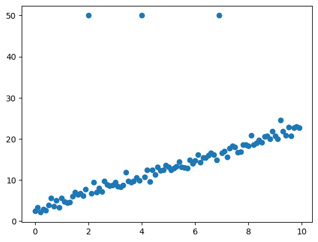

```python
plt.figure()
plt.plot(tab_lin[:,0], tab_lin[:,1], 'o')
plt.show()
```

- This data set clearly shows spurious datapoints
- Let's get rid of them

```python
tab_bool = tab_lin[:, 1] != 50
print(tab_bool)
```

```
[ True  True  True  True  True  True  True  True  True  True  True  True
  True  True  True  True  True  True  True  True False  True  True  True
  True  True  True  True  True  True  True  True  True  True  True  True
  True  True  True  True False  True  True  True  True  True  True  True
  True  True  True  True  True  True  True  True  True  True  True  True
  True  True  True  True  True  True  True  True  True False  True  True
  True  True  True  True  True  True  True  True  True  True  True  True
  True  True  True  True  True  True  True  True  True  True  True  True
  True  True  True  True]
```

- The condition was applied on the second column (the ordinates).
- Then the indexing will be performed on all the rows to remove the bad ones (both x and y).

```python
tab_lin_corr = tab_lin[tab_bool]
print(tab_lin_corr)
```

```
[[ 0.          2.45252343]
 [ 0.1         3.29543351]
 [ 0.2         2.10148584]
 [ 0.3         2.82416863]
 [ 0.4         2.63562906]
 [ 0.5         3.83124062]
 [ 0.6         5.60251378]
 [ 0.7         3.62974467]
 [ 0.8         5.06920258]
 [ 0.9         3.34477602]
 [ 1.          5.60903762]
 [ 1.1         4.78003719]
 [ 1.2         4.47725909]
 [ 1.3         4.52322212]
 [ 1.4         6.0135451 ]
 [ 1.5         7.07137561]
 [ 1.6         6.38950896]
 [ 1.7         6.71431208]
 [ 1.8         6.19391808]
 [ 1.9         7.72718322]
 [ 2.1         6.67086374]
 [ 2.2         9.43858252]
 [ 2.3         7.02606485]
 [ 2.4         8.01438352]
 [ 2.5         7.21736514]
 [ 2.6         9.67166132]
 [ 2.7         8.84101915]
 [ 2.8         8.57449218]
 [ 2.9         8.68084292]
 [ 3.          9.46730967]
 [ 3.1         8.49298879]
 [ 3.2         8.36591824]
 [ 3.3         8.72509809]
 [ 3.4        11.83125366]
 [ 3.5         9.74270215]
 [ 3.6         9.44174773]
 [ 3.7         9.7722622 ]
 [ 3.8        10.55804216]
 [ 3.9         9.92090769]
 [ 4.1        10.71630317]
```

[output cut: 42 more lines]

```
 [ 8.5        19.11791169]
 [ 8.6        20.56401416]
 [ 8.7        20.65606624]
 [ 8.8        19.99524599]
 [ 8.9        21.88752918]
 [ 9.         20.76642719]
 [ 9.1        19.99019028]
 [ 9.2        24.56679851]
 [ 9.3        21.79419226]
 [ 9.4        20.86535285]
 [ 9.5        22.89450147]
 [ 9.6        20.76625258]
 [ 9.7        22.63083525]
 [ 9.8        22.98440152]
 [ 9.9        22.67485881]]
```

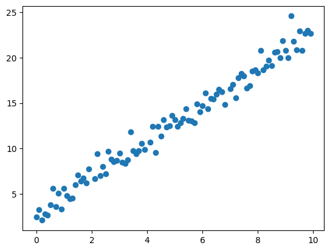

```python
plt.figure()
plt.plot(tab_lin_corr[:,0], tab_lin_corr[:,1], 'o')
plt.show()
```

- One last usefull trick for boolean arrays.
  - Python use boolean as 0 and 1 integers.
  - Summing an array of boolean (with the `sum` function) gives the number of `True` values

```python
print(len(tab_bool))

print(np.sum(tab_bool)) # Number of True

print(np.sum((~tab_bool))) # Number of False
```

```
100
97
3
```

## II-5 Data Fitting

- As physicist we often have to fit dataset with a model to extract information about physical parameters.
- The **Scipy** library offers a bunch of statiscal and mathematical function to adress this.
- We'll se here how to perform curve fitting with the least square method.
- (Other methods such as maximum likelihood are also possible with **scipy** but won't be covered here)

### II-5-a Least square method

- How to compare experimental (or simulation) data with uncertainties to a theoritical model ?
- Let's have a dataset $\mathbf{y}= \{y_1, y_2, \dots , y_n\}$ with uncertainties $\mathbf{\sigma}= \{\sigma_1, \sigma_2, \dots , \sigma_n\}$, correspondint to datapoints $\mathbf{x}= \{x_1, x_2, \dots , x_n\}$.
- Let's also have a model $f(\mathbf{x} | \mathbf{\theta})$, with unknown parameters $\mathbf{\theta} = \{\theta_1, \theta_2, \dots, \theta_k\}$
- One can define the quadratic sum $S(\mathbf{\theta})$ of the variations of the measurements to the predicted values from the model $f(\mathbf{x}, \mathbf{\theta})$ :

$$S(\mathbf{\theta}) = \sum_{i=1}^{n}(y_{i}-f(x_{i} | \mathbf{\theta}))^2 = \sum_{i=1}^{n} r_i^2(\mathbf{\theta})$$

where $r_i^2(\theta)$ are the residuals.

- As we know the uncertainties (one standard deviation) $\sigma_i$, we'll use instead the quantty :

$$\chi^2(\theta) = \sum_{i=1}^{n}\left(\frac{y_{i}-f(x_{i} | \theta)}{\sigma_i}\right)^2$$

(Worst variable name ever. $\chi^2(\theta)$ is just the name, it's not the square of $\chi(\theta)$ !)

- The least square method consits of finding the parameters $\mathbf{\theta}$ that minimize the $\chi^2(\mathbf{\theta})$.
- The obtained parameters will be the closest one to fit the model on the dataset.
- This is done by solving $$grad\chi^2(\mathbf{\theta})=0$$
- But there is in general no analytical solution for this (except for linear model).

$\Rightarrow$ **Scipy** propose function to calculate an approximative solution (by default by the Levenberg-Marquardt algorithm).

$\Rightarrow$ This is done by the `curve_fit` function from the `scipy.optimize` library.

```python
import scipy.optimize as opt
```

- Let's study a dataset corresponding to an exponential decay as a function of time. It is saved in the *data_exp_fit.npy* file (a structured array).

```python
data = np.load('data_exp_fit.npy')
print(data.dtype)
```

```
[('t', '<f8'), ('y', '<f8'), ('s', '<f8')]
```

```python
t = data["t"]
y = data["y"]
s = data["s"]
```

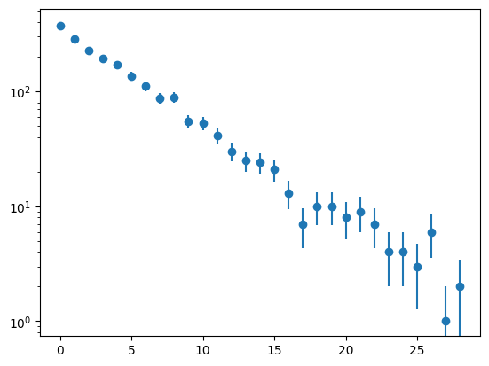

```python
plt.figure()
plt.errorbar(t, y, yerr=s, fmt='o')
plt.yscale('log')
plt.show()
```

- Let's now make a model function to be fit: $$f(t|(A, \tau) = Ae^{-t/\tau}$$

```python
def expo_func(t, A, tau):
    return A * np.exp(-t / tau)
```

- To help the fitter, we estimate initial parameters value:
  - for $A$ we take the max value of $y$
  - for $\tau$ we can take the mean value of $t$ weighted by $y$.
- They will be the $p_0$ parameter (a tuple).

```python
A0 = np.max(y)
tau0 = np.sum(t*y) / (np.sum(y))
p0 = (A0, tau0)
print(p0)
```

```
(370.0, 4.591182364729459)
```

- Let's check is $p_0$ is not to bad:

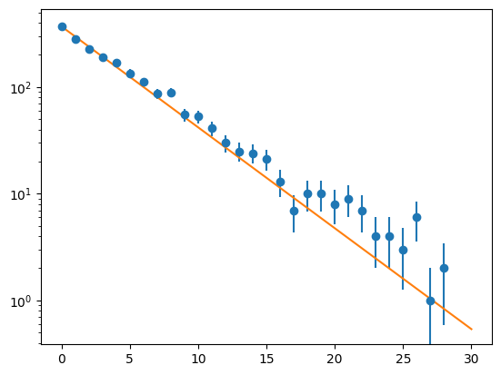

```python
t_fit = np.arange(0, 30, 0.001)
y_fit = expo_func(t_fit, p0[0], p0[1])

plt.figure()
plt.errorbar(t, y, yerr=s, fmt='o')
plt.plot(t_fit, y_fit)
plt.yscale('log')
plt.show()
```

- Now we can fit the data using `curve_fit`:

```python
popt, pcov = opt.curve_fit(expo_func, t, y, sigma=s, p0=p0, absolute_sigma=True)
perr = np.sqrt(np.diag(pcov))

print(popt) # Optimized paramters
print("---")
print(pcov) # Covariance matrix
print("---")
print(perr) # Fit paruncertainties
```

```
[355.00958394   5.07594623]
---
[[ 1.20633098e+02 -9.19125947e-01]
 [-9.19125947e-01  1.48360418e-02]]
---
[10.98330998  0.12180329]
```

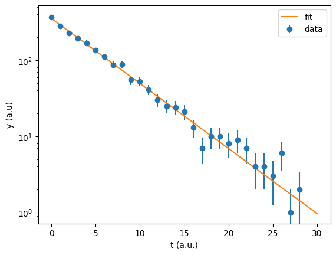

```python
t_fit = np.arange(0, 30, 0.001)
y_fit = expo_func(t_fit, popt[0], popt[1])

plt.figure()
plt.errorbar(t, y, yerr=s, fmt='o', label="data")
plt.plot(t_fit, y_fit, label='fit')
plt.yscale('log')
plt.legend()
plt.xlabel("t (a.u.)")
plt.ylabel("y (a.u)")
plt.show()
```